# C3.10 曲げにおける降伏強度および極限強度

## C3.11 複雑な曲げに対する別のより正確な方法

純粋な外力による曲げモーメントに抵抗するとき、梁の断面は中立軸と呼ばれる軸のまわりに曲がる。与えられた外力モーメントに対して梁の断面形状がどのようなものであっても、曲げが発生する軸が存在する。一般的なケースとしては、非対称な梁の断面や、非弾性領域において圧縮と引張で異なる応力-ひずみ曲線を持つ材料が挙げられる。したがって、中立軸は断面の図心を通らないため、解決方法は試行錯誤的なアプローチとなる。解決手順は第A19章第A19.17節に概説されているため、ここでは繰り返さない。また、座屈しないウェブを持つ梁の設計を扱う章では、梁断面全体の極限曲げ抵抗がどのように決定されるかを説明し、示している。

## C3.12 組合せ曲げおよびたわみ剪断下の強度

本章のこれまでの部分では、純粋曲げにおける梁断面の強度の決定について扱ってきた。通常の梁の設計問題は、曲げを伴うたわみ剪断を伴う。真の内部抵抗モーメントを見つけるにあたり、Cozzoneの簡易手法では、真の内部応力システムと同じ内部抵抗モーメントを生み出す台形の曲げ応力分布を導き出す。その後、真の曲げモーメントも与える三角形の応力システムが導かれる。

ここで、三角形の曲げ応力分布に対するたわみ剪断応力の式は次のようになる。

$$fs = \frac{VQ}{It}
\qquad\text{--- (A)}$$

したがって、台形曲げ応力に対して式(A)を使用するには、補正係数 (C) を適用する必要があり、式(A)は以下のようになる。

$$fs = \frac{CVQ}{It}
\qquad\text{--- (B)}$$

補正係数 (C) がどのように決定されるかを示すために、例題 (2) で使用された I形梁断面を使用する。

極限設計モーメント $14000\text{ in. lbs.}$ は、梁の固定端から $23.30\text{ インチ}$ の位置で片持ち梁に作用する $600\text{ lbs.}$ の荷重によって生じると仮定する。したがって、支持部における梁断面は $14000$ の曲げモーメントと $V = 600\text{ lbs.}$ の剪断力を受ける。問題はこの組合せ荷重下における安全余裕（マージン・オブ・セーフティ）を求めることである。

純粋曲げのみに対する応力比は以下の通りである。

$$Rb = \frac{M}{Ma} = \frac{14000}{15000} = .933$$

（ $15000$ の値は例題2から得られたものである）。

剪断における応力比は $Rs = fs/Fsu$ であり、ここで $fs$ はたわみ剪断応力、 $Fsu$ は材料の極限剪断応力である。したがって、問題は $fs$ の値を求めることである。

設計曲げモーメント $14000\text{ in. lbs.}$ に対して、等価な台形および三角形の曲げ応力分布が決定される。

三角形の応力変化に対して、

$$Fb = \frac{Mc}{I} = \frac{14000}{0.358} = 39150\text{ psi}$$

例題 (2) より、形状係数 $k$ は $1.17$ であった。Fig. C3.19において、 $k = 1.17$ の曲線がプロットされている。左側の目盛りの $Fb$ 応力 $39150$ から始めて、 $k = 1.17$ の曲線との交点まで水平に進み、そこから垂直に下に投影して、応力-ひずみ曲線および $fo$ 曲線との交点から $fm$ に対して $35800$ 、 $fo$ に対して $19700$ を得る。応力の結果は Fig. C3.28a および Fig. C3.28b にグラフで示されている。

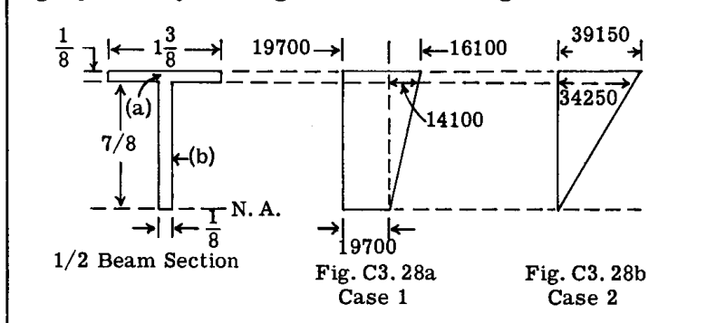

Fig. C3.28a, Fig. C3.28b

たわみ剪断応力は曲げ応力の変化率の関数である。したがって、2つの応力分布図における曲げ応力を比較することにより、剪断補正係数 C を得ることができる。

この特定の問題では、剪断応力は中立軸において最大となる。中立軸より上側の梁断面に作用する全法線力は、応力に面積を乗じたものに等しい。

簡略化のために、梁断面を (a) および (b) とラベルされた2つの部分に分割する。

**ケース 1 の場合：-**

部分 (a) に作用する荷重は、

$$19700 \times 1.375 \times 0.125 = 3380\text{ lb.}$$

$$\frac{16100 + 14100}{2} \times 1.375 \times 0.125 = 2600\text{ lb.}$$

部分 (b)

$$19700 \times 0.875 \times 0.125 = 2155$$

$$14100 \times 0.5 \times 0.875 \times 0.125 = 771$$

$$\text{全荷重} \quad 8906\text{ lbs.}$$

**ケース 2 の場合：-**

部分 (a)

$$\frac{39150 + 34250}{2} \times 1.375 \times 0.125 = 6300$$

部分 (b)

$$34250 \times 0.5 \times 0.875 \times 0.125 = 1874\text{ lbs.}$$

$$\text{合計} \quad 8174\text{ lbs.}$$

したがって、補正係数は、

$$C = \frac{8906}{8174} = 1.09$$

このとき、中立軸における $fs$ は、

$$fs = \frac{CVQ}{It} = \frac{1.09 \times 600 \times 0.209}{0.358 \times
0.125} = 3060\text{ psi.}$$

この特定のマグネシウム材料の極限剪断応力は $19000\text{ psi}$ である。（材料特性に関する章を参照のこと。）

$$\text{応力比 } Rs = \frac{fs}{Fsw} = \frac{3060}{19000} = 0.161$$

組合せ曲げおよびたわみ剪断に対する相関式は以下の通りである。

$$Rb^2 + Rs^2 = 1$$

これより、

$$\text{安全余裕 (Margin of Safety)} = \frac{1}{\sqrt{Rb^2 + Rs^2}} - 1$$

または、

$$\text{M.S.} = \frac{1}{\sqrt{.933^2 + .161^2}} - 1 = .05$$

このように、たわみ剪断応力の影響により、純粋曲げにおける安全余裕は .07 であったものが、組合せ応力作用下では .05 に低下した。

剪断補正係数 C のさらなる計算として、梁断面の部分 (b) の上端における剪断応力に対する値を決定する。この点に対する補正係数は、ケース1とケース2の応力パターンについて部分 (a) に作用する荷重を比較することによって求められる。

**ケース 1.** 部分 (a) に作用する荷重 $= 3380 + 2600 = 5980$

**ケース 2.** 部分 (a) に作用する荷重 $= 6300$

したがって、

$$C = \frac{5980}{6300} = .95$$

## C3.13 組合せ曲げ・たわみ剪断および軸圧縮下の強度

組合せ荷重下における極限強度設計の主題は、後の章で詳細に扱われる。

組合せ曲げ、剪断および軸荷重に対する保守的な相関式は以下の通りである。

$$(Ra + Rb)^2 + Rs^2 = 1$$

または、

$$\text{M.S.} = \frac{1}{\sqrt{(Ra + Rb)^2 + Rs^2}} - 1$$

$Rb$ には、軸荷重にたわみを乗じたものによる二次曲げモーメントの影響が含まれる。

## C3.14 $fm$ および $fo$ のさらなる値

Table C3.2 は、航空宇宙構造分野で一般的な他のいくつかの材料に対する $fm$ および $fo$ の降伏値および極限値を示している。曲げにおける降伏および極限係数 $Fb$ は、以下の式に代入することによって求められる。

$$Fb = fm + fo(k - 1)$$

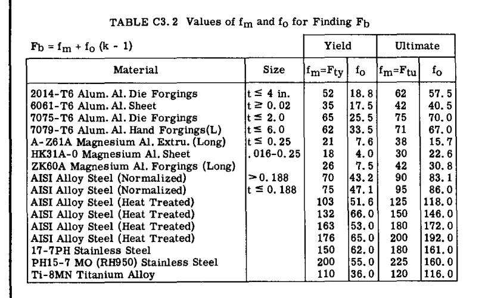

TABLE C3.2

## 問題

1. 外径 $1\text{-}1/2\text{ インチ}$ 、肉厚 $.095\text{ インチ}$ の丸管がある。これは Fig. C3.2 に示される応力-ひずみ曲線を持つアルミニウム合金で作られている。もし、圧縮における最大単位ひずみが $.008$ に制限される場合、この断面はどのような曲げ抵抗モーメントを発生させるか。（注：応力-ひずみ曲線は引張と圧縮で異なる形状を持つため、中立軸は中心線軸と一致しない。したがって、試行錯誤法を使用すること。）
2. 問題 (1) と同様であるが、外径 $1\text{-}1/4\text{ インチ}$ 、肉厚 $.081\text{ インチ}$ の角管を使用する場合。

以下の問題を解くには、Cozzoneの方法を使用せよ。

3. 以下の各梁断面が、主軸のまわりに曲げられたときに発生する極限曲げモーメントを、以下の各材料について求めよ。
1. 7075-T6 アルミニウム合金押出材。  
   $Ftu = 75000$ , $Fty = 65000$
2. Ti-6Al-4V チタン合金。  
   $Ftu = 130000$ , $Fty = 120000$

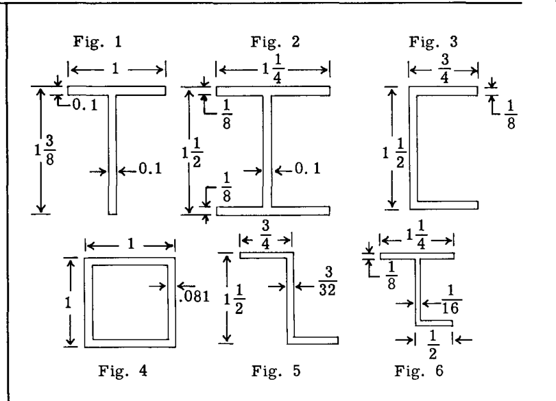

Fig. 1, Fig. 2, Fig. 3, Fig. 4, Fig. 5, Fig. 6

4. 単純支持された梁の長軸スパンが $24\text{ インチ}$ である。梁の高さは $2\text{ インチ}$ に制限されている。梁の中央に $4000\text{ lbs.}$ の極限荷重を支持しなければならない。材料は 7075-T6 アルミニウム合金押出材である。この荷重を支持するための I形断面を設計せよ。押出形状で使用されるコーナーフィレットの面積は無視してよい。